# Prediction Personal Activity

Lloyd Low

25/06/2017

## Executive summary

Prediction of personal activity and correctness in which one performs weight lifting exercise is of interest to many people. Data from accelerometers on the belt, forearm, arm, and dumbell were collected from 6 participants. They were asked to perform barbell lifts correctly and incorrectly in 5 different ways. This report shows the use of a random forest model with 4-fold cross validation being used to predict 20 tests datasets with unknown outcomes (i.e. the “classe” variable, which corresponds to the manner they did the exercise).

Data source: http://groupware.les.inf.puc-rio.br/har

## Tidy the dataset and explore it

There are many missing values and empty cells in the given dataset. Removal of these missing values is the first step. Next, variables that do not seem to be predictors are removed as well. The trimmed dataset is explored for how the remaining variables are correlated with each other. There seem to be a number of highly correlated variables, which are those marked as dark red and dark blue in the correlation plot.

```r
# Tidy up training and testing dataset and explore the trimmed dataset
library(corrplot)
library(caret)

#read in training and testing dataset with empty cells converted to "NA"
pml_train <- read.csv("pml-training.csv", header = TRUE, na.strings = c("NA", ""))
pml_test <- read.csv("pml-testing.csv", header = TRUE, na.strings = c("NA", ""))

#remove columns that contain "NA" in train dataset
pml_train_trim <- pml_train[,colSums(is.na(pml_train)) == 0]
#remove the same columns in test dataset to be consistent and check no "NA" exist in columns
pml_test_trim <- pml_test[,colSums(is.na(pml_train)) == 0]
sum(colSums(is.na(pml_test_trim)))
```

```
## [1] 0
```

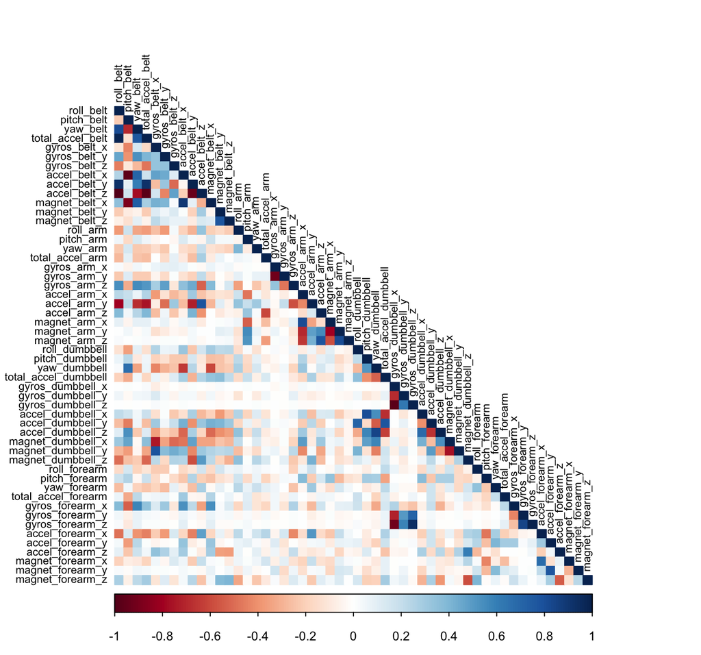

```r
#further remove variables that don't seem to be predictors i.e. "X","user_name",
#"raw_timestamp_part_1","raw_timestamp_part_2","cvtd_timestamp","new_window","num_window"
pml_train_trim <- pml_train_trim[,8:60]
pml_test_trim <- pml_test_trim[,8:60]

#Check how correlated the variables are to each other
cor_mx <- cor(pml_train_trim[, -53])
corrplot(cor_mx, order = "original", method = "color", type = "lower", tl.cex = 0.7,tl.col = "black")
```

```r
## Partition data to model_train, model_test, preprocess with PCA, fitted with random forest
inTrain = createDataPartition(y = pml_train_trim$classe, p = 0.7, list = FALSE)
model_train = pml_train_trim[inTrain, ]
model_test = pml_train_trim[-inTrain, ]

#Model fit, cross validate K-fold = 4, maintain 80% variation from PCA for speed
modelFit <- train(classe ~ ., method = "rf", preProcess = "pca", data = model_train,
                  trControl = trainControl(method = "cv", number = 4,
                                           preProcOptions = list(thresh = 0.8)))
```

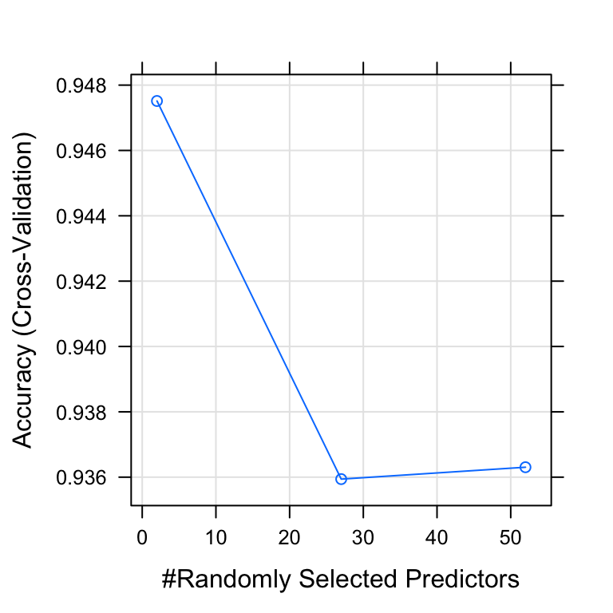

```r
plot(modelFit)
```

## Prediction out of sample accuracy

The accuracy of the set aside 30% of the data is about 95.6%. Activity labeled “E” seems quite distinct from the others making it easier to predict from the rest of the outcome variables with rooms to further improve the accuracy by setting the PCA preprocessing threshold higher.

```r
#Prediction on model_test and evaluate out of sample accuracy
pred_valid_rf <- predict(modelFit, model_test)
confuse_mx <- confusionMatrix(model_test$classe, pred_valid_rf)
confuse_mx$table
```

```
##           Reference
## Prediction    A    B    C    D    E
##          A 1615   16   22   18    3
##          B   32 1066   32    2    7
##          C    4   20  991   10    1
##          D   11    8   46  895    4
##          E    2    7    7    9 1057
```

```r
confuse_mx <- confusionMatrix(model_test$classe, pred_valid_rf)$overall[1]
confuse_mx
```

```
## Accuracy
##  0.95565
```

```r
outOfSampleError <- 1 - confusionMatrix(model_test$classe, pred_valid_rf)$overall[[1]]
outOfSampleError
```

```
## [1] 0.04435004
```

```r
#Prediction on the 20 unknowns test cases given in the assignment
pred_final <- predict(modelFit, pml_test_trim[, -53])
pred_final
```

```
##  [1] B A A A A E D B A A A C B A E E A B B B
## Levels: A B C D E
```